Skip to main content

# Q1 – Which cell populations are most altered in schizophrenia and bipolar disorder?

Cell-type composition analysis (propeller) in the HBCC cohort

Author

Myriam Sijlimassi

**NoteHow to read this notebook**

Each step starts with a short explanation of **what we do and why**, then the code. Every figure comes with:

- a **legend** (“Figure Q1-Fxx”), written so that it can be copied into the report or the appendix;
- a **“How to read”** box, to understand the figure without knowing the method;
- an **“Interpretation”** box with the HBCC results.

The donors and the numbers of nuclei come from the preprocessing (notebook `01_preprocessing.qmd`). The composition test runs in this notebook (a few seconds); the test function is in `scripts/utils_composition.R`. Figures are saved as `.png` (300 dpi) in `04_FIGURES/Q1_composition/`. References are numbered in square brackets and listed at the end.

# Overview

## Question and hypothesis

**Central question of the project.** Do schizophrenia (SCZ) and bipolar disorder (BD) share cell-type-specific molecular alterations in the human prefrontal cortex, and could these changes reflect accelerated ageing and affect neuronal and glial signalling networks?

**Question of this notebook (Q1).** *Which neuronal and glial populations show the strongest alterations in SCZ and BD?* We answer it at the level of **cell-type composition**: does the proportion of each cell type change with the disease?

**Hypothesis tested.** In the full PsychAD atlas, Lee et al. [1] report that psychiatric disorders are mainly associated with more neurons, especially deep-layer (L5-6) excitatory neurons. We test whether this signal is found in the HBCC cohort alone, and whether it is shared by SCZ and BD.

| Notebook | Answers | Gives to the next questions |
| --- | --- | --- |
| Preprocessing | which donors, which data | donors, Seurat object, pseudobulk matrix |
| **Q1 – this notebook** | *where?* which cell types change in proportion | the cell types whose number changes (microglia, oligodendrocytes) |
| Q2 – pseudobulk DE | *what?* which genes change in SCZ and in BD | the table of all tested genes |
| Q3 – pathway enrichment | *which functions?* | - |
| Q4 – cell communication | *which signals?* | - |
| Q5 – ageing | *accelerated ageing?* | - |

## The principle behind every step

**We compare people, not cells.** A brain that gives 5,000 nuclei is still one person. Treating nuclei as independent samples (pseudoreplication) makes p-values far too small [2]. The proportions are therefore computed per **donor**, and the donor is the statistical unit of every test.

## Plan

| Step | What we do | Output |
| --- | --- | --- |
| 1 | Composition per donor and per group (description) | Q1-F01, Q1-F02 |
| 2 | Composition test with propeller | Q1-F03 |
| 3 | Sensitivity analyses: does the result hold? | Q1-F04 |

# Setup

| Package | Used for |
| --- | --- |
| `speckle` | `propeller`: cell-type composition test [3] |
| `limma` | linear model used by propeller [4] |
| `ggplot2`, `knitr` | figures and tables |

```r
the.seed <- 2026
set.seed(the.seed)

suppressPackageStartupMessages({
  library(ggplot2)
  library(knitr)
})

source("scripts/utils_figures.R")       # common figure style, colours and saving (shared with the other notebooks)
source("scripts/utils_composition.R")   # propeller test (main and sensitivity analyses)
packageVersion("speckle")         # recorded for the report
```

```
[1] '1.12.0'
```

All the choices are gathered in one place, so the analysis can be re-run with other values.

| Parameter | Value | Why |
| --- | --- | --- |
| `fdr_threshold` | 0.05 | threshold on the Benjamini–Hochberg adjusted p-value (FDR) [5], the same as in the other questions |
| covariates | age, sex, genetic ancestry | ancestry is strongly unbalanced between groups; no post-mortem interval in the file |
| `min_ancestry_size` | 10 donors | ancestries with fewer donors are pooled into “Other”, so that the model stays stable |
| contrasts | SCZ vs controls, BD vs controls, SCZ vs BD | the three comparisons of the project question |

```r
# Inputs (outputs of the preprocessing notebook)
proc_dir <- "../01_DATA/processed"            # selected donors, nuclei per donor and subclass

# Outputs
out_dir <- "../03_RESULTS/Q1_composition"
fig_dir <- "../04_FIGURES/Q1_composition"
for (d in c(out_dir, fig_dir)) dir.create(d, recursive = TRUE, showWarnings = FALSE)

# Analysis choices
fdr_threshold        <- 0.05
min_ancestry_size    <- 10

# Colours of the groups, the same in every figure of the project (blue = SCZ, red = BD)
col_groups <- c(Control = "grey60", SCZ = "#2166ac", BD = "#b2182b")
```

```r
# Selected donors
donors <- readRDS(file.path(proc_dir, "donor_classification.rds"))
sel    <- donors[donors$group != "Excluded", ]

# Nuclei per donor and per subclass (all nuclei)
counts <- as.matrix(read.csv(file.path(proc_dir, "nuclei_donor_x_subclass.csv"), check.names = FALSE, row.names = 1))
counts <- counts[sel$donor_id, ]

# Covariates of the model
donor_info <- data.frame(donor    = sel$donor_id,
                         group    = factor(sel$group, levels = c("Control", "SCZ", "BD")),
                         age      = as.numeric(sel$age),
                         sex      = factor(sel$sex),
                         ancestry = as.character(sel$genetic_ancestry))
small_ancestries <- names(which(table(donor_info$ancestry) < min_ancestry_size))
donor_info$ancestry[donor_info$ancestry %in% small_ancestries] <- "Other"
donor_info$ancestry <- factor(donor_info$ancestry)

table(donor_info$ancestry, donor_info$group)
```

```
           Control SCZ BD
  African       70  32  4
  European      43  12 45
  Other          3   2  2
  unknown        5   3  3
```

```r
cat("Donors:", nrow(counts), "| cell types:", ncol(counts), "| nuclei:", format(sum(counts), big.mark = ","), "\n")
```

```
Donors: 224 | cell types: 27 | nuclei: 1,123,085
```

# Composition of the cell types

## Step 1 – Composition per donor and per group

**What we do and why.** Before any test, we look at the proportion of each cell type in each donor. The proportions of a donor always add up to 100 % (compositional data): if one cell type increases, the others decrease mechanically.

```r
proportions <- counts / rowSums(counts)

long <- data.frame(donor    = rep(rownames(proportions), times = ncol(proportions)),
                   subclass = rep(colnames(proportions), each = nrow(proportions)),
                   share    = as.vector(proportions))
long$group <- donor_info$group[match(long$donor, donor_info$donor)]
```

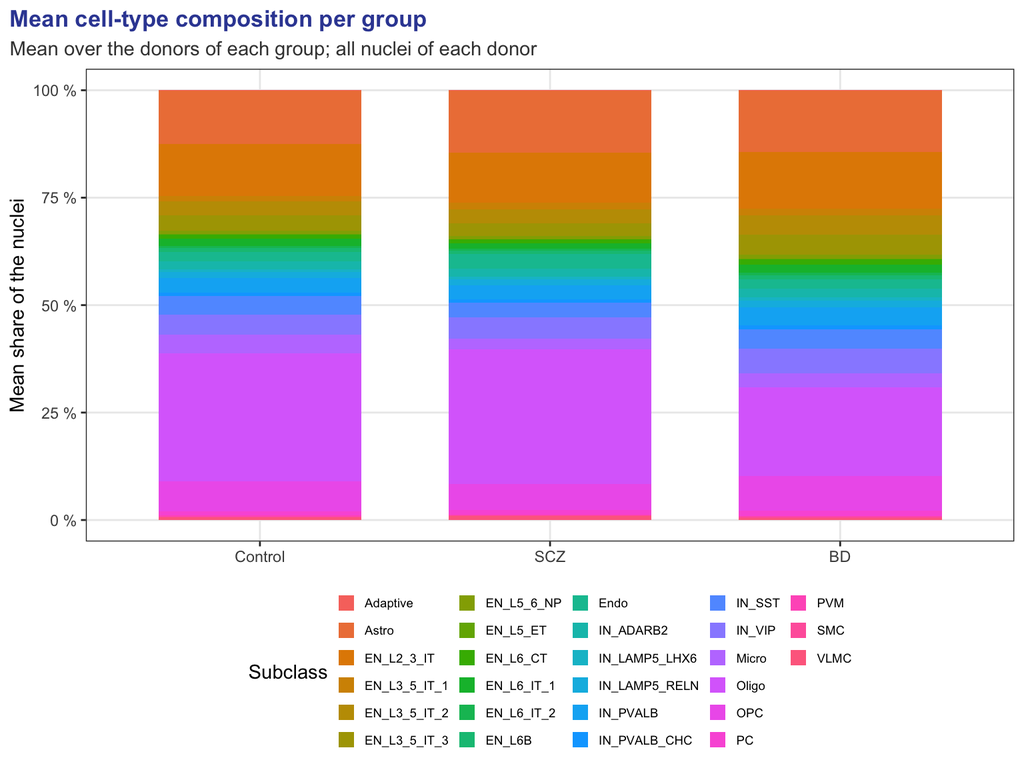

Figure 1

```r
mean_share <- aggregate(share ~ group + subclass, data = long, FUN = mean)

p_Q1_F01 <- ggplot(mean_share, aes(group, share, fill = subclass)) +
  geom_col(width = 0.7) +
  scale_y_continuous(labels = function(x) paste0(round(100 * x), " %")) +
  labs(x = NULL, y = "Mean share of the nuclei", fill = "Subclass",
       title = "Mean cell-type composition per group",
       subtitle = "Mean over the donors of each group; all nuclei of each donor") +
  theme_project() +
  theme(legend.key.size = unit(0.35, "cm"), legend.text = element_text(size = 7))
p_Q1_F01
save_figure(p_Q1_F01, "Q1_F01_mean_composition", fig_dir, width = 8, height = 6)
```

**Figure Q1-F01 – Mean cell-type composition per group.** Mean proportion of each of the 27 subclasses among the nuclei of a donor, averaged over the donors of each group (1,123,085 nuclei in total).

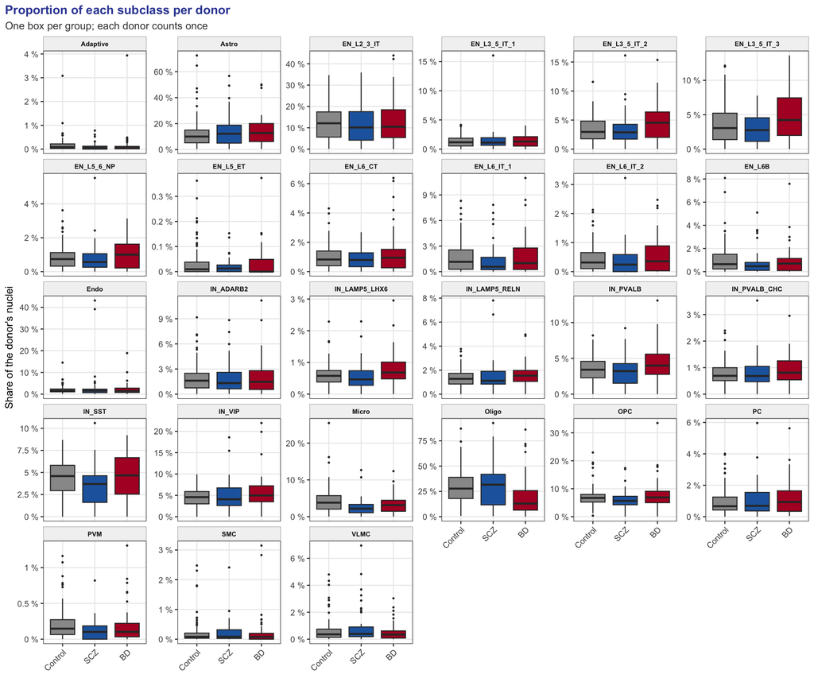

Figure 2

```r
p_Q1_F02 <- ggplot(long, aes(group, share, fill = group)) +
  geom_boxplot(outlier.size = 0.5) +
  facet_wrap(~ subclass, scales = "free_y", ncol = 6) +
  scale_fill_manual(values = col_groups, guide = "none") +
  scale_y_continuous(labels = function(x) paste0(round(100 * x, 1), " %")) +
  labs(x = NULL, y = "Share of the donor's nuclei",
       title = "Proportion of each subclass per donor",
       subtitle = "One box per group; each donor counts once") +
  theme_project() +
  theme(strip.text = element_text(size = 7), axis.text.x = element_text(angle = 45, hjust = 1))
p_Q1_F02
save_figure(p_Q1_F02, "Q1_F02_proportions_per_donor", fig_dir, width = 12, height = 10)
```

**Figure Q1-F02 – Proportion of each subclass per donor.** Box plots (median, interquartile range, outliers) of the share of each subclass among the nuclei of a donor, per group. Y axes are free: compare the groups within a panel, not between panels.

**TipHow to read**

In each panel, a box shifted up or down compared with the controls suggests a change in proportion. Overlapping boxes mean that the variability between donors is larger than the difference between groups.

**ImportantInterpretation**

- **The variability between donors is huge** (oligodendrocytes from almost 0 % to 93 % of a donor’s nuclei, astrocytes up to 73 %), and the boxes of the three groups overlap in every panel.
- Two shifts are visible by eye: fewer oligodendrocytes in BD and fewer microglia in SCZ. This is description only; the test is Step 2.
- The proportion of oligodendrocytes mostly depends on how much white matter was dissected with the cortex: a difference there may be a dissection effect.
- Deep-layer neurons are absent in some donors (for example EN_L6_IT_2 in 36 donors), probably a dissection effect too.

## Step 2 – Composition test with propeller

**What we do and why.** Proportions cannot be compared with a simple test, because they always add up to 100 %: if one cell type increases, the others decrease. `propeller` [3] is a method made for this situation:

1. for each donor, compute the share of each cell type;
2. transform these shares so that they can be analysed like ordinary measurements;
3. for each cell type, compare the groups while taking age, sex and ancestry into account (`limma` [4]);
4. correct for the fact that 27 cell types are tested (false discovery rate, FDR [5]).

```r
three_comparisons <- list(c("Control", "SCZ"), c("Control", "BD"), c("BD", "SCZ"))   # c(reference, tested)
main <- test_composition(counts, donor_info, three_comparisons)

# One row per subclass, one column per contrast
short_name <- c(SCZ_vs_Control = "SCZ_vs_Ctl", BD_vs_Control = "BD_vs_Ctl", SCZ_vs_BD = "SCZ_vs_BD")
results <- data.frame(subclass = unique(main$subclass))
for (k in c("FDR", "ratio", "t")) for (contrast in names(short_name)) {
  part <- main[main$contrast == contrast, ]
  results[[paste0(k, "_", short_name[[contrast]])]] <- part[[k]][match(results$subclass, part$subclass)]
}
```

**WarningReading the propeller output**

In the source code of `propeller.ttest`, `Tstatistic`, `P.Value` and `FDR` come from the **adjusted** model (age, sex, ancestry), whereas `PropRatio` is **not adjusted**: it is the ratio of the raw mean proportions of the two groups. We therefore read the direction of the adjusted effect on the t statistic.

| contrast | subclass | t | FDR |
| --- | --- | --- | --- |
| SCZ vs controls | Micro | -3.42 | 0.020 |
| BD vs controls | Micro | -3.03 | 0.037 |
| BD vs controls | Oligo | -3.18 | 0.037 |

Figure 3

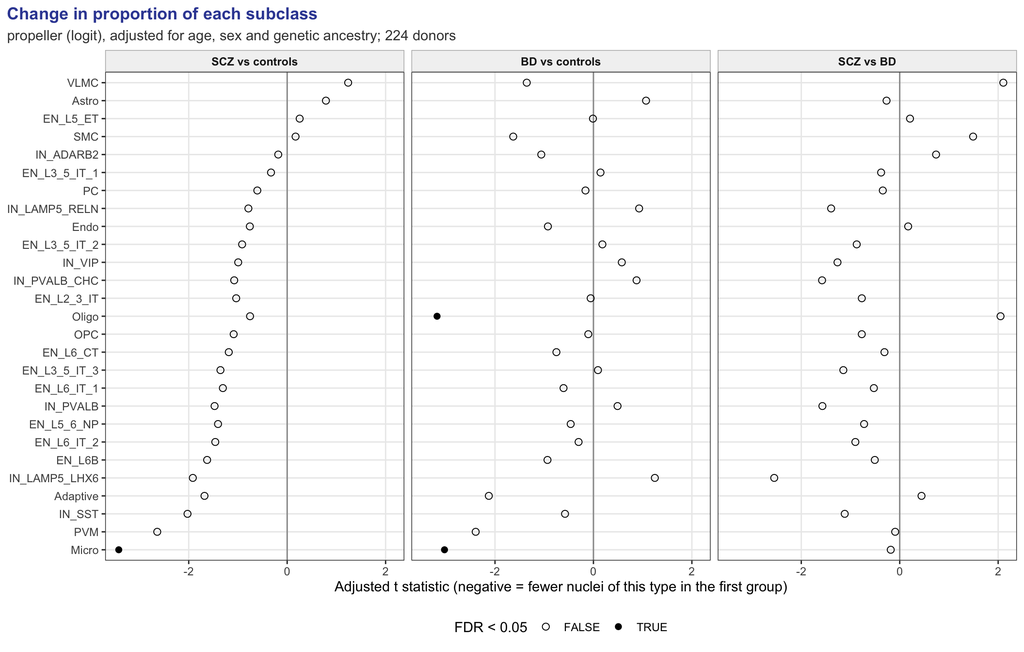

Figure 4

```r
contrast_labels <- c(SCZ_vs_Control = "SCZ vs controls", BD_vs_Control = "BD vs controls", SCZ_vs_BD = "SCZ vs BD")
effects <- main
effects$contrast    <- factor(contrast_labels[effects$contrast], levels = contrast_labels)
effects$significant <- effects$FDR < fdr_threshold

p_Q1_F03 <- ggplot(effects, aes(t, reorder(subclass, t), shape = significant)) +
  geom_vline(xintercept = 0, colour = "grey60") +
  geom_point(size = 2.2) +
  scale_shape_manual(values = c("FALSE" = 1, "TRUE" = 16), name = paste0("FDR < ", fdr_threshold)) +
  facet_wrap(~ contrast) +
  labs(x = "Adjusted t statistic (negative = fewer nuclei of this type in the first group)", y = NULL,
       title = "Change in proportion of each subclass",
       subtitle = paste0("propeller (logit), adjusted for age, sex and genetic ancestry; ", nrow(counts), " donors")) +
  theme_project()
p_Q1_F03
save_figure(p_Q1_F03, "Q1_F03_propeller_t", fig_dir, width = 11, height = 7)

significant <- effects[effects$significant, c("contrast", "subclass", "t", "FDR")]
significant$t   <- round(significant$t, 2)
significant$FDR <- signif(significant$FDR, 2)
rownames(significant) <- NULL
significant
```

**Figure Q1-F03 – Change in proportion of each cell subclass in SCZ and BD.** Adjusted t statistic of the propeller test (logit transformation, linear model with age, sex and genetic ancestry) for each of the 27 subclasses, in SCZ vs controls, BD vs controls and SCZ vs BD (224 donors). Filled dots: Benjamini-Hochberg FDR < 0.05. The table below the figure gives the significant results.

**TipHow to read**

Each dot is a subclass. Left of the vertical line: fewer nuclei of this type in the first group of the comparison (for example fewer in SCZ than in controls). The further from 0, the stronger the evidence. Only filled dots pass the threshold fixed in advance.

**ImportantInterpretation**

- **Microglia are less abundant in SCZ (FDR 0.02) and in BD (FDR 0.037) than in controls**, with no difference between the two disorders (FDR 0.9 for SCZ vs BD): a shared change of the immune compartment. Perivascular macrophages (PVM) show the same trend without passing the threshold. This is an association, not a mechanism: treatment or the conditions of death are possible explanations that this cohort cannot test.
- **Oligodendrocytes are less abundant in BD** (FDR 0.037), but this is the result most exposed to a dissection effect.
- **SCZ vs BD: no significant difference.** With limited power and ancestry confounding, this means “no difference detected”, not “no difference”.
- **Deep-layer (L5-6) neurons: no change.** The increase reported in the full atlas [1] is not found in HBCC alone, which has far fewer donors.

## Step 3 – Does the result hold? (sensitivity analyses)

**What we do and why.** We run the same test again, changing one thing at a time. These analyses were decided before seeing the results. A result that holds in every variant is robust; a result that disappears has to be discussed.

```r
deep_layers    <- c("EN_L5_6_NP", "EN_L6_IT_1", "EN_L6_IT_2", "EN_L6B", "EN_L6_CT")
key_subclasses <- c("Micro", "Oligo", deep_layers)

# B. without the donors with fewer than 1,000 nuclei (imprecise proportions)
keep_B <- rowSums(counts) >= 1000
# C. without the oligodendrocytes: proportions recomputed among the other nuclei
counts_C <- counts[, colnames(counts) != "Oligo"]
# D. SCZ vs controls in donors of African ancestry only
keep_D <- donor_info$ancestry == "African" & donor_info$group %in% c("Control", "SCZ")
# E. BD vs controls in donors of European ancestry only
keep_E <- donor_info$ancestry == "European" & donor_info$group %in% c("Control", "BD")
# F. without the donors with 0 nuclei in a deep layer (dissection effect)
missing_deep_layer <- apply(counts[, deep_layers] == 0, 1, any)
keep_F <- !missing_deep_layer

all_variants <- rbind(
  data.frame(analysis = "A_main",                             main),
  data.frame(analysis = "B_without_donors_under_1000_nuclei", test_composition(counts[keep_B, ], donor_info[keep_B, ], three_comparisons)),
  data.frame(analysis = "C_without_oligodendrocytes",         test_composition(counts_C, donor_info, three_comparisons)),
  data.frame(analysis = "D_African_ancestry_only",            test_composition(counts[keep_D, ], donor_info[keep_D, ], list(c("Control", "SCZ")))),
  data.frame(analysis = "E_European_ancestry_only",           test_composition(counts[keep_E, ], donor_info[keep_E, ], list(c("Control", "BD")))),
  data.frame(analysis = "F_all_deep_layers_present",          test_composition(counts[keep_F, ], donor_info[keep_F, ], three_comparisons)))

sensitivity <- all_variants[all_variants$subclass %in% key_subclasses, c("analysis", "subclass", "contrast", "t", "FDR")]
sensitivity$t   <- round(sensitivity$t, 2)
sensitivity$FDR <- signif(sensitivity$FDR, 2)
rownames(sensitivity) <- NULL

# Are the donors without a deep layer distributed in the same way in the three groups? (donor-level test)
deep_table  <- table(missing_deep_layer, donor_info$group)
deep_fisher <- fisher.test(deep_table)
deep_table
```

```
missing_deep_layer Control SCZ  BD
             FALSE     101  36  41
             TRUE       20  13  13
```

| Variant | Donors | Question |
| --- | --- | --- |
| A. main analysis | 224 | reference |
| B. without donors with fewer than 1,000 nuclei | 212 | do imprecise proportions drive the result? |
| C. without oligodendrocytes | 224 | does the drop of oligodendrocytes create effects elsewhere? |
| D. donors of African ancestry only | 70 controls, 32 SCZ | does the SCZ effect hold without the ancestry imbalance? |
| E. donors of European ancestry only | 43 controls, 45 BD | does the BD effect hold without the ancestry imbalance? |
| F. donors with all deep layers present | 178 | does the dissection of deep layers change the result? |

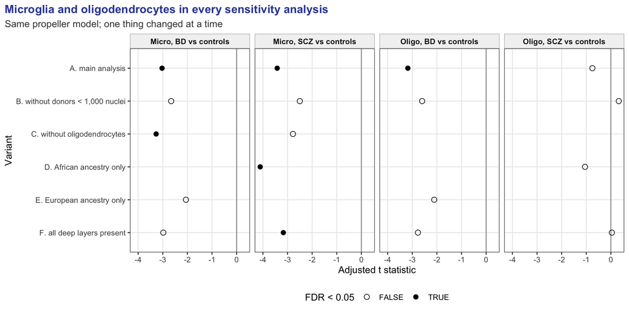

Figure 5

```r
sens <- sensitivity[sensitivity$subclass %in% c("Micro", "Oligo") &
                    sensitivity$contrast %in% c("SCZ_vs_Control", "BD_vs_Control"), ]
sens$panel <- paste0(sens$subclass, ", ", sub("_vs_Control", " vs controls", sens$contrast))
variant_labels <- c(A_main                             = "A. main analysis",
                    B_without_donors_under_1000_nuclei = "B. without donors < 1,000 nuclei",
                    C_without_oligodendrocytes         = "C. without oligodendrocytes",
                    D_African_ancestry_only            = "D. African ancestry only",
                    E_European_ancestry_only           = "E. European ancestry only",
                    F_all_deep_layers_present          = "F. all deep layers present")
sens$variant     <- factor(variant_labels[sens$analysis], levels = rev(variant_labels))
sens$significant <- sens$FDR < fdr_threshold

p_Q1_F04 <- ggplot(sens, aes(t, variant, shape = significant)) +
  geom_vline(xintercept = 0, colour = "grey60") +
  geom_point(size = 2.5) +
  scale_shape_manual(values = c("FALSE" = 1, "TRUE" = 16), name = paste0("FDR < ", fdr_threshold)) +
  facet_wrap(~ panel, nrow = 1) +
  labs(x = "Adjusted t statistic", y = "Variant",
       title = "Microglia and oligodendrocytes in every sensitivity analysis",
       subtitle = "Same propeller model; one thing changed at a time") +
  theme_project()
p_Q1_F04
save_figure(p_Q1_F04, "Q1_F04_sensitivity", fig_dir, width = 10, height = 5)

micro_D <- sensitivity[sensitivity$analysis == "D_African_ancestry_only" & sensitivity$subclass == "Micro", ]
bd_E    <- sensitivity[sensitivity$analysis == "E_European_ancestry_only" & sensitivity$subclass %in% c("Micro", "Oligo"), ]
```

**Figure Q1-F04 – Robustness of the main Q1 results.** Adjusted t statistic of the propeller test for microglia and oligodendrocytes in the main analysis (A) and in five sensitivity analyses (B-F, see the table above). Filled dots: FDR < 0.05. Missing dots: the comparison was not run in that variant.

**TipHow to read**

If the dots of a panel stay on the same side of 0 in every variant, the direction of the effect is robust. A dot moving towards 0 in a smaller variant can reflect a loss of power rather than a disappearing effect.

**ImportantInterpretation**

- **Microglia in SCZ: the most robust result.** Same direction in every variant, and the strongest effect in donors of African ancestry only (t = -4.11, FDR 0.0021): ancestry does not explain it.
- **Microglia and oligodendrocytes in BD:** same direction everywhere, but weaker in donors of European ancestry only (FDR 0.29 and 0.29). Loss of power (88 donors instead of 224) or partly an ancestry effect: we cannot tell them apart.
- Removing oligodendrocytes does not create any effect on neurons (variant C): no mechanical artefact of composition.
- Donors without deep layers are not unbalanced between groups (17 % of Control, 27 % of SCZ, 24 % of BD; Fisher exact test p = 0.23).

**Saving the results.** The propeller results of every subclass and the sensitivity analyses are saved in `03_RESULTS/Q1_composition/`.

```r
smallest_FDR <- pmin(results$FDR_SCZ_vs_Ctl, results$FDR_BD_vs_Ctl, results$FDR_SCZ_vs_BD)
results <- results[order(smallest_FDR), ]
write.csv(results, file.path(out_dir, "Q1_propeller_results.csv"), row.names = FALSE)
write.csv(sensitivity, file.path(out_dir, "Q1_sensitivity.csv"), row.names = FALSE)
```

# Conclusion

| Element | Result | Figure |
| --- | --- | --- |
| Donors analysed | 224 (121 controls, 49 SCZ, 54 BD), one brain bank | preprocessing |
| Main limit | genetic ancestry confounded with diagnosis | preprocessing |
| Main composition change | fewer microglia in SCZ and in BD, shared | Q1-F03 |
| Most robust result | fewer microglia in SCZ, also in African-ancestry donors only | Q1-F04 |
| Fragile result | fewer oligodendrocytes in BD (dissection, ancestry) | Q1-F03, Q1-F04 |
| SCZ vs BD | no difference detected | Q1-F03 |
| Hypothesis of [1] (more L5-6 neurons) | not found in HBCC | Q1-F03 |

**Answer to Q1.** Cell-type composition changes very little in SCZ and BD. The only robust change is a lower proportion of microglia, shared by the two disorders (FDR 0.02 in SCZ, 0.037 in BD) and still present in donors of African ancestry only. Oligodendrocytes are less abundant in BD, but this result is exposed to dissection and ancestry. No cell type differs between SCZ and BD. Q2 to Q5 therefore analyse all the subclasses with enough donors, not only those that change in number: a cell type can change its expression without changing in proportion.

**In one sentence:** in the HBCC cohort, the only robust change in cell-type composition is a lower proportion of microglia, shared by schizophrenia and bipolar disorder and clearer in schizophrenia, where it persists after stratification on ancestry.

**Is the hypothesis supported?** No. The increase of deep-layer (L5-6) excitatory neurons reported in the full PsychAD atlas [1] is not found in HBCC. The atlas pooled SCZ and BD, and several cohorts with far more donors; we analyse each disorder separately, in one cohort.

**Our results in the light of the literature.** The largest single-nucleus study of SCZ found no change in the proportion of any cell type in the prefrontal cortex [6], in line with the small changes we find. Histological studies of SCZ found no lower microglial density, but a loss of mature microglial markers [7]. Our lower proportion of microglial nuclei could therefore reflect a change of microglial state rather than a loss of cells, but we did not test this. In BD, fewer oligodendrocyte-lineage cells have been reported in the frontal cortex, but not in SCZ [8], which agrees with the change we see in BD only.

**Links with the other questions.**

- **Q2 (genes)**: the cell types with the most genes changed in both disorders, upper-layer excitatory neurons and astrocytes, do not change in number.
- **Q3 (functions)**: microglia are fewer in both disorders, and their remaining cells share inflammatory pathways in SCZ and BD.
- **Q5 (ageing)**: microglia look older in SCZ, and oligodendrocytes in both disorders; most of the older-looking cell types do not change in number.

# Limits

- **Ancestry confounded with diagnosis**: adjusted for and stratified, but it cannot be removed.
- **Dissection**: the share of oligodendrocytes depends on the white matter dissected; deep layers are missing in some donors.
- **Power**: 49 SCZ and 54 BD donors; a non-significant result is not evidence of no effect.
- **No post-mortem interval and no information on treatments**: covariates limited to age, sex and ancestry.
- **Donors with few nuclei**: 12 donors with fewer than 1,000 nuclei (minimum 61); variant B.
- **Observational post-mortem study**: we report associations, never causes.

# List of figures

| Figure | File | What it shows |
| --- | --- | --- |
| Q1-F01 | `Q1_F01_mean_composition` | mean composition per group |
| Q1-F02 | `Q1_F02_proportions_per_donor` | proportions per donor |
| Q1-F03 | `Q1_F03_propeller_t` | propeller results |
| Q1-F04 | `Q1_F04_sensitivity` | sensitivity analyses |

```r
sort(list.files(fig_dir, pattern = "\\.png$"))
```

```
[1] "Q1_F01_mean_composition.png"      "Q1_F02_proportions_per_donor.png"
[3] "Q1_F03_propeller_t.png"           "Q1_F04_sensitivity.png"
```

# References

1. Lee D. et al. (2026). Single-cell atlas of transcriptomic vulnerability across brain disorders. *Nature*, 657, 988–1002. doi:10.1038/s41586-025-09573-z
2. Squair J. W. et al. (2021). Confronting false discoveries in single-cell differential expression. *Nature Communications*, 12, 5692.
3. Phipson B. et al. (2022). propeller: testing for differences in cell type proportions in single cell data. *Bioinformatics*, 38, 4720-4726.
4. Ritchie M. E. et al. (2015). limma powers differential expression analyses for RNA-sequencing and microarray studies. *Nucleic Acids Research*, 43, e47.
5. Benjamini Y. and Hochberg Y. (1995). Controlling the false discovery rate: a practical and powerful approach to multiple testing. *Journal of the Royal Statistical Society B*, 57, 289-300.
6. Ruzicka W. B. et al. (2024). Single-cell multi-cohort dissection of the schizophrenia transcriptome. *Science*, 384, eadg5136.
7. Snijders G. J. L. J. et al. (2021). A loss of mature microglial markers without immune activation in schizophrenia. *Glia*, 69, 1251–1267.
8. Hayashi Y. et al. (2012). Neuropathological similarities and differences between schizophrenia and bipolar disorder: a flow cytometric postmortem brain study. *PLoS ONE*, 7, e33019.